# Image Recognition with Tensorflow

This notebook shows how to perform image recognition with Tensorflow. We run our classifiers on the MNIST corpus, which contains 28x28 pixel handwritten digits. The corpus is split into 55,000 records for training , 5,000 for validation and 10,000 for testing.

We will organize this notebook as follows. Section 1 imports some libraries and prepare the environment. Section 2 constructs a linear classifer (Multinomial Logistic Regression / Softmax) with a vanilla Gradient Descent Optimizer and perform classification over the MNIST corpus. Section 3 still classifies the MNIST corpus, but this time with a fully-connected deep neural network and Adam Optimizer. We will later see how deep neural network improves the accruacy for image recognition.

1. Initialize the Environment
2. Linear Classifer with Multinomial Logistic Regression (Softmax)
3. Fully Connected Deep Neural Networks

## 1. Initialize the Environment

Must execute this section before shallow or deep learning.

```python
import tensorflow as tf
from tensorflow.examples.tutorials.mnist import input_data

import numpy as np
import pylab
import math
import os

%matplotlib inline
```

```python
tf.reset_default_graph()
sess = tf.Session()
```

```python
# Download the MNIST dataset to '/tmp/tf.minist.data' if no local copies
mnist = input_data.read_data_sets('/tmp/tf.minist.data', one_hot=True)
```

```
Extracting /tmp/tf.minist.data/train-images-idx3-ubyte.gz
Extracting /tmp/tf.minist.data/train-labels-idx1-ubyte.gz
Extracting /tmp/tf.minist.data/t10k-images-idx3-ubyte.gz
Extracting /tmp/tf.minist.data/t10k-labels-idx1-ubyte.gz
```

```python
NUM_CLASSES = 10
NUM_PIXELS = 28 * 28
```

## 2. Linear Classifer with Multinomial Logistic Regression (Softmax)

The section constructs a multinomial logistic regression (softmax) classifer for training the MNIST corpus. The classifer will use gradient descent for optimization and cross-entropy for the loss function.

```
Train, validation, test: 55000, 5000, 10000
[ 0.  0.  0.  1.  0.  0.  0.  0.  0.  0.]
3
784
```

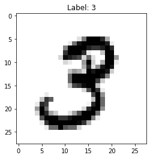

```python
# There are 55k, 5k, and 10k examples in train, validation, and test.
print ('Train, validation, test: %d, %d, %d' %
      (len(mnist.train.images), len(mnist.validation.images), len(mnist.test.images)))

index=1

# The format of the labels is 'one-hot'.
# For example, '5' is represented as '[ 0.  0.  0.  0.  0.  1.  0.  0.  0.  0.]'
print (mnist.train.labels[index])

# You can find the index of the label, like this:
print (np.argmax(mnist.train.labels[index]))

# An image is a 'flattened' array of 28*28 = 784 pixels.
print (len(mnist.train.images[index]))

# To display an image, first reshape it to 28x28
pylab.imshow(mnist.train.images[index].reshape((28,28)), cmap=pylab.cm.gray_r)
pylab.title('Label: %d' % np.argmax(mnist.train.labels[index]))
```

```python
TRAIN_STEPS = 4000
BATCH_SIZE = 100
LEARNING_RATE = 0.5
```

```python
# Define inputs
images = tf.placeholder(dtype=tf.float32, shape=[None, NUM_PIXELS])
labels = tf.placeholder(dtype=tf.float32, shape=[None, NUM_CLASSES])
```

```python
# Define model
W = tf.Variable(tf.truncated_normal([NUM_PIXELS, NUM_CLASSES]))
b = tf.Variable(tf.zeros([NUM_CLASSES]))
y = tf.matmul(images, W) + b
```

```python
# Define loss and optimizer
loss = tf.reduce_mean(tf.nn.softmax_cross_entropy_with_logits(logits=y, labels=labels))
train_step = tf.train.GradientDescentOptimizer(LEARNING_RATE).minimize(loss)
```

```python
# Initialize variables after the model is defined
sess.run(tf.global_variables_initializer())
```

```python
# Train the model
for i in range(TRAIN_STEPS):
    batch_images, batch_labels = mnist.train.next_batch(BATCH_SIZE)
    sess.run(train_step, feed_dict={images: batch_images, labels: batch_labels})
```

```python
# Evaluate the trained model
correct_prediction = tf.equal(tf.argmax(y, 1), tf.argmax(labels, 1))
accuracy = tf.reduce_mean(tf.cast(correct_prediction, tf.float32))

print("Accuracy %f" % sess.run(accuracy, feed_dict={images: mnist.test.images,
                                                    labels: mnist.test.labels}))
```

```
Accuracy 0.908300
```

Define the following functions to plot the first n images classified as a certain digit.

```python
import matplotlib.pyplot as plt
import matplotlib.gridspec as gridspec
from math import ceil

prediction = tf.argmax(y, 1)
def predict(imgIndex):
    image = mnist.test.images[imgIndex]
    actual_label = np.argmax(mnist.test.labels[imgIndex])
    predict_label = sess.run(prediction, feed_dict={images: [image]})
    return predict_label, actual_label

def plot_variants(number, numfigs):
    j = 0
    c = 10 # columns of plots
    r = ceil(float(numfigs) / c)
    n = r * c
    plt.rcParams["figure.figsize"] = (10,10)
    fig, ax = plt.subplots(r, c)
    #fig.set_size_inches(r*1.5, c*1.5)
    gs1 = gridspec.GridSpec(r, c)
    gs1.update(wspace=0.05, hspace=0.025) # set the spacing between axes.

    for i in range(len(mnist.test.images)):
        if j >= numfigs:
            if j < n:
                ax[j].axis('off')
                j += 1
                continue
            else:
                break
        predicted, actual = predict(i)
        predicted = int(predicted)
        if predicted == number:
            ax1 = plt.subplot(gs1[j])
            ax1.imshow(mnist.test.images[i].reshape((28,28)), cmap=pylab.cm.gray_r)
            ax1.axis('off')
            ax1.set_aspect('equal')
            ax1.set_title(i)   # set img index as figure title
            j += 1

    plt.show()
```

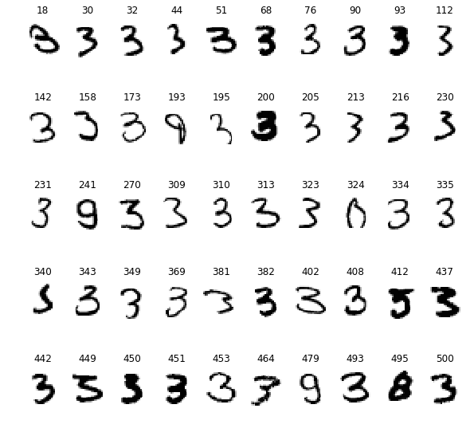

```python
# plot the first 50 images our multinomial logistic regression classifies to digit "3"
plot_variants(number=3, numfigs=50)
```

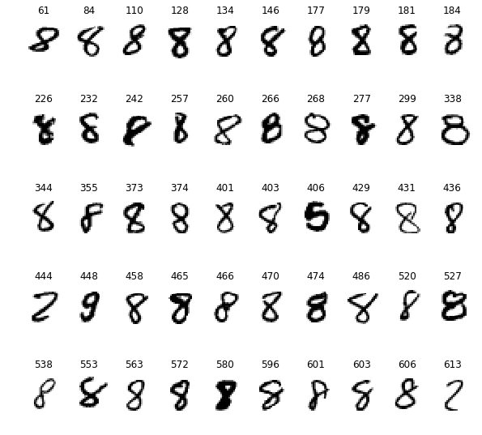

```python
# plot the first 50 images classifed as digit "8"
plot_variants(8, 50)
```

We can see that some digits were misclassfied as "3" or "8" by the Multinomial Logistic Regression. The next section will use deep learning to improve the accruacy of image recogintion.

## 3. Fully Connected Deep Neural Networks

In this section, we will build a fully connected deep neural network with multiple layers and train it on the same MNIST corpus. Notable change include:

- Switch from a linear classifier to a deep neural network
- Visualize graph and summary data in TensorBoard.
- Use AdamOptimizer instead of the vanilla GradientDescentOptimizer for optimization
- Use Dropout in the second layer to prevent overfitting

```python
from math import sqrt
```

```python
# number of neurons in each hidden layer
HIDDEN1_SIZE = 500
HIDDEN2_SIZE = 250

# experiment with the number of training steps to see the effect
TRAIN_STEPS = 2000
BATCH_SIZE = 100

# we're using a different learning rate than the previous
# notebook, and a new optimizer
LEARNING_RATE = 0.001
```

```python
# Define inputs
with tf.name_scope('input'):
    images = tf.placeholder(tf.float32, [None, NUM_PIXELS], name="pixels")
    labels = tf.placeholder(tf.float32, [None, NUM_CLASSES], name="labels")
```

```python
# Function to create a fully connected layer
# Initialize the variables that have an affect on how quickly training converges
def fc_layer(input, size_out, name="fc", activation=None):
    with tf.name_scope(name):
        size_in = int(input.shape[1])

        # Choose a strategy for weights
        w = tf.Variable(tf.truncated_normal([size_in, size_out], stddev=0.1), name="weights")
        #w = tf.Variable(tf.truncated_normal(shape=[size_in, size_out], stddev=1.0 / sqrt(float(size_in))))

        b = tf.Variable(tf.constant(0.1, shape=[size_out]), name="bias")
        wx_plus_b = tf.matmul(input, w) + b
        if activation: return activation(wx_plus_b)
        return wx_plus_b
```

```python
# Define the model

# First, we'll create two fully connected layers, with ReLU activations
fc1 = fc_layer(images, HIDDEN1_SIZE, "fc1", activation=tf.nn.relu)
fc2 = fc_layer(fc1, HIDDEN2_SIZE, "fc2", activation=tf.nn.relu)

# Next, we'll apply Dropout to the second layer
# This is optional but can help prevent overfitting
dropped = tf.nn.dropout(fc2, keep_prob=0.9)

# Finally, we'll calculate logists. This will be
# the input to our Softmax function. Notice we
# don't apply an activation at this layer.
# If you've commented out the dropout layer,
# switch the input here to 'fc2'.
y = fc_layer(dropped, NUM_CLASSES, name="output")
```

```python
# Define loss and an optimizer
with tf.name_scope("loss"):
    loss = tf.reduce_mean(tf.nn.softmax_cross_entropy_with_logits(logits=y, labels=labels))
    tf.summary.scalar('loss', loss)

with tf.name_scope("optimizer"):
    # Whereas in the previous section we used a vanilla GradientDescentOptimizer
    # here, we're using Adam. This is a single line of code change, and more
    # importantly, TensorFlow will still automatically analyze our graph
    # and determine how to adjust the variables to decrease the loss.
    train = tf.train.AdamOptimizer(LEARNING_RATE).minimize(loss)
```

```python
# Define evaluation
with tf.name_scope("evaluation"):
    # these there lines are identical to the previous notebook.
    correct_prediction = tf.equal(tf.argmax(y, 1), tf.argmax(labels, 1))
    accuracy = tf.reduce_mean(tf.cast(correct_prediction, tf.float32))
    tf.summary.scalar('accuracy', accuracy)
```

```python
LOGDIR = './graphs'
# Set up logging.
# We'll use a second FileWriter to summarize accuracy on
# the test set. This will let us display it nicely in TensorBoard.
train_writer = tf.summary.FileWriter(os.path.join(LOGDIR, "train"))
train_writer.add_graph(sess.graph)
test_writer = tf.summary.FileWriter(os.path.join(LOGDIR, "test"))
summary_op = tf.summary.merge_all()
```

```python
sess.run(tf.global_variables_initializer())
```

```python
for step in range(TRAIN_STEPS):
    batch_xs, batch_ys = mnist.train.next_batch(BATCH_SIZE)
    summary_result, _ = sess.run([summary_op, train],
                                    feed_dict={images: batch_xs, labels: batch_ys})

    train_writer.add_summary(summary_result, step)
    train_writer.add_run_metadata(tf.RunMetadata(), 'step%03d' % step)

    # calculate accuracy on the test set, every 100 steps.
    # we're using the entire test set here, so this will be a bit slow
    if step % 100 == 0:
        summary_result, acc = sess.run([summary_op, accuracy],
                                       feed_dict={images: mnist.test.images,
                                                  labels: mnist.test.labels})
        test_writer.add_summary(summary_result, step)
        test_writer.add_run_metadata(tf.RunMetadata(), 'step%03d' % step)
        print ("test accuracy: %f at step %d" % (acc, step))


print("Accuracy %f" % sess.run(accuracy,
                               feed_dict={images: mnist.test.images,
                                          labels: mnist.test.labels}))
train_writer.close()
test_writer.close()
```

```
test accuracy: 0.178400 at step 0
test accuracy: 0.922200 at step 100
test accuracy: 0.937700 at step 200
test accuracy: 0.954000 at step 300
test accuracy: 0.958000 at step 400
test accuracy: 0.961000 at step 500
test accuracy: 0.963000 at step 600
test accuracy: 0.962000 at step 700
test accuracy: 0.968200 at step 800
test accuracy: 0.968100 at step 900
test accuracy: 0.970500 at step 1000
test accuracy: 0.971100 at step 1100
test accuracy: 0.973500 at step 1200
test accuracy: 0.974700 at step 1300
test accuracy: 0.971700 at step 1400
test accuracy: 0.974900 at step 1500
test accuracy: 0.975800 at step 1600
test accuracy: 0.976700 at step 1700
test accuracy: 0.977900 at step 1800
test accuracy: 0.974400 at step 1900
Accuracy 0.977800
```

Great! The deep neural network classfifer has brought our accuracy up from 0.9083 to 0.9778. Let's plot some of the digits it classfies and compare them with what we have in the previous section.

```python
prediction = tf.argmax(y, 1)
def predict(imgIndex):
    image = mnist.test.images[imgIndex]
    actual_label = np.argmax(mnist.test.labels[imgIndex])
    predict_label = sess.run(prediction, feed_dict={images: [image]})
    return predict_label, actual_label

def plot_variants_deep(number, numfigs):
    j = 0
    c = 10 # columns of plots
    r = ceil(float(numfigs) / c)
    n = r * c
    plt.rcParams["figure.figsize"] = (10,10)
    fig, ax = plt.subplots(r, c)
    #fig.set_size_inches(r*1.5, c*1.5)
    gs1 = gridspec.GridSpec(r, c)
    gs1.update(wspace=0.05, hspace=0.025) # set the spacing between axes.

    for i in range(len(mnist.test.images)):
        if j >= numfigs:
            if j < n:
                ax[j].axis('off')
                j += 1
                continue
            else:
                break
        predicted, actual = predict(i)
        predicted = int(predicted)
        if predicted == number:
            ax1 = plt.subplot(gs1[j])
            ax1.imshow(mnist.test.images[i].reshape((28,28)), cmap=pylab.cm.gray_r)
            ax1.axis('off')
            ax1.set_aspect('equal')
            ax1.set_title(i)   # set img index as figure title
            j += 1

    plt.show()
```

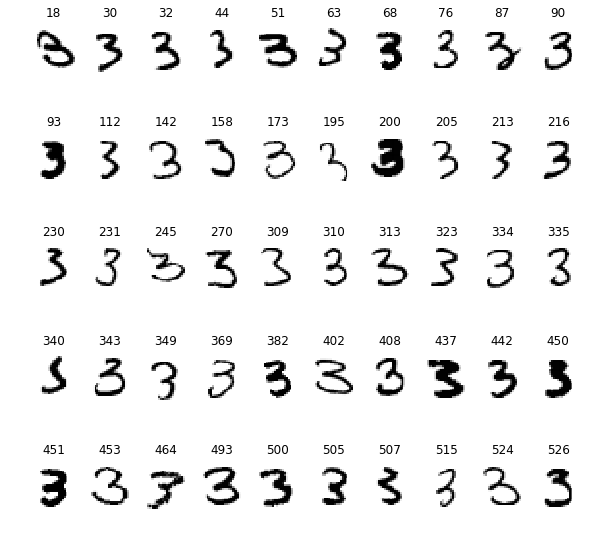

```python
# Again, plot the first 50 images our multinomial logistic regression classifies to digit "3"
plot_variants(number=3, numfigs=50)
```

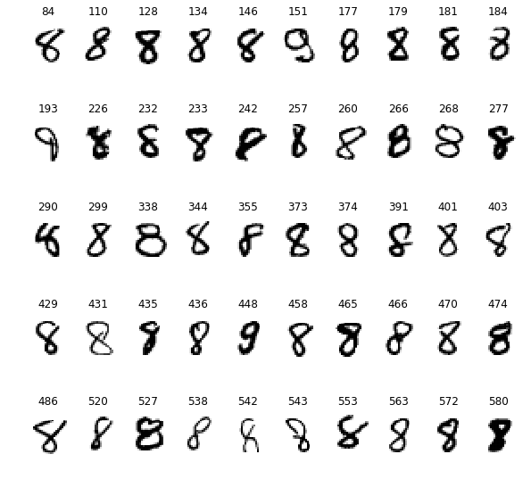

```python
# plot the first 50 images classifed as digit "8"
plot_variants(8, 50)
```

See? Most of the digits were classfied correctly! Image recognition is one of the most popular areas for deep learning.